# STSCI 5065 - Homework 2

Harry Lu

dl947

# Question 1 (18 pts)

Let’s assume that there exists a 5 GB file. For all below sub-parts, assume that transfer rate is 50 MB/s and seek time is 3 milliseconds. Remember from class, seek time is the time to find the start position of Each block to read the data from. For simplicity, assume that 1GB = 1000 MB, 1 MB = 1000 KB and so on, and the complete file is stored on just one system.

## a) (5 pts)

If the file is stored on a simple file system with a block size of 100 KB, how much time does it take to read the complete file?

$$\begin{align}\text{Total Time}&=\text{Total Seek Time}+\text{Transfer Time}\\&=\text{Seek Time/Block}\times\text{Number of Blocks}+\text{Transfer Time}\end{align}$$

$$\begin{align}\text{Transfer Time}&=\frac{5\text{GB}}{50\text{MB}\cdot\text{s}^{-1}}\\&=100\text{s}\end{align}$$

$$\text{Seek Time/Block}=3\cdot10^{-3}\text{s}$$

$$\begin{align}\text{Number of Blocks}&=\frac{5\text{GB}}{100\text{KB}}\\&=5\cdot10^4\end{align}$$

$$\begin{align}\text{Total Time}&=100\text{s}+3\cdot10^{-3}\text{s}\times5\cdot10^4\\&=100\text{s}+150\text{s}\\&=250\text{s}\end{align}$$

The total time is 250s.

## b) (5 pts)

If the file is stored on a Hadoop file system with a block size of 100 MB, how much time does it take to read the complete file?

$$\begin{align}\text{Total Time}&=\text{Total Seek Time}+\text{Transfer Time}\\&=\text{Seek Time/Block}\times\text{Number of Blocks}+\text{Transfer Time}\end{align}$$

$$\begin{align}\text{Transfer Time}&=\frac{5\text{GB}}{50\text{MB}\cdot\text{s}^{-1}}\\&=100\text{s}\end{align}$$

$$\text{Seek Time/Block}=3\cdot10^{-3}\text{s}$$

$$\begin{align}\text{Number of Blocks}&=\frac{5\text{GB}}{100\text{MB}}\\&=50\end{align}$$

$$\begin{align}\text{Total Time}&=100\text{s}+3\cdot10^{-3}\text{s}\times50\\&=100\text{s}+0.15\text{s}\\&=100.15\text{s}\end{align}$$

The total time is 100.15s.

## c) (5 pts)

What is the percentage gain of time in the second case as compared to the first case?

```r
(250-100.15)/250*100
```

```
## [1] 59.94
```

The percentage gain is 59.94%.

## d) (3 pts)

Give reasons and situations where block size in Question 1a is better than block size in Question 1b, and vice versa.

When the file size is very small, the number of blocks would be small, and the total seek time would be very similar between two situations. Also, if there are a lot of small files that need to be processed, in this case, there is no need to use Hadoop file system.

When the file size is very large and there is only a few files, Hadoop file system is better.

# Question 2 (12 pts)

In this question we will be working with the command line interface on the Hortonworks Sandbox and use commands for working in the Hadoop ecosystem. Remember the username to login is “root” and password is “Hadoop”(for the first time). For each of the below sub-question, write the command you executed to perform the task.

## a)

Create an HDFS directory called `course-data` at the root of the Hadoop filesystem.

```
[root@sandbox ~]# hadoop fs -mkdir /course-data
```

```
[root@sandbox /]# hadoop fs -ls /
Found 13 items
drwxrwxrwx   - yarn   hadoop          0 2016-10-25 08:10 /app-logs
drwxr-xr-x   - hdfs   hdfs            0 2016-10-25 07:54 /apps
drwxr-xr-x   - yarn   hadoop          0 2016-10-25 07:48 /ats
drwxr-xr-x   - root   hdfs            0 2019-03-09 22:46 /course-data
drwxr-xr-x   - hdfs   hdfs            0 2016-10-25 08:01 /demo
drwxr-xr-x   - hdfs   hdfs            0 2016-10-25 07:48 /hdp
drwxr-xr-x   - mapred hdfs            0 2016-10-25 07:48 /mapred
drwxrwxrwx   - mapred hadoop          0 2016-10-25 07:48 /mr-history
drwxr-xr-x   - hdfs   hdfs            0 2016-10-25 07:47 /ranger
drwxrwxrwx   - spark  hadoop          0 2019-03-09 22:50 /spark-history
drwxrwxrwx   - spark  hadoop          0 2016-10-25 08:14 /spark2-history
drwxrwxrwx   - hdfs   hdfs            0 2016-10-25 08:11 /tmp
drwxr-xr-x   - hdfs   hdfs            0 2016-10-25 08:11 /user
```

## b)

Create a normal directory `data-set` at the root of the normal Linux file system.

```
[root@sandbox ~]# mkdir /data-set
```

```
[root@sandbox /]# ls
bin   cgroups_test  dev  hadoop  kafka-logs  lib64       media  nohup.out  packer-files  root  selinux  sys  usr      var
boot  data-set      etc  home    lib         lost+found  mnt    opt        proc          sbin  srv      tmp  vagrant
```

## c)

Download the files from the following locations in the directory data-set and unzip it. It may take some time to download them.

- http://data.gdeltproject.org/events/1990.zip
- http://data.gdeltproject.org/events/1991.zip

```
[root@sandbox /]# cd data-set
[root@sandbox data-set]# wget http://harrylu.net/CU/5065/1990.zip
[root@sandbox data-set]# wget http://harrylu.net/CU/5065/1991.zip
```

```
[root@sandbox data-set]# ls
1990.zip  1991.zip
```

```
[root@sandbox data-set]# unzip 1990.zip
[root@sandbox data-set]# unzip 1991.zip
```

## d)

After extraction of the above files, copy the files into Hadoop filesystem.

```
[root@sandbox data-set]# ls
1990.csv  1990.zip  1991.csv  1991.zip
```

```
[root@sandbox data-set]# hadoop fs -copyFromLocal 1990.csv /course-data
[root@sandbox data-set]# hadoop fs -copyFromLocal 1991.csv /course-data
```

## e)

Write the command to validate if the files are actually copied correctly in the system.

```
[root@sandbox data-set]# hadoop fs -ls /course-data
Found 2 items
-rw-r--r--   1 root hdfs  302854981 2019-03-09 23:11 /course-data/1990.csv
-rw-r--r--   1 root hdfs  395395368 2019-03-09 23:12 /course-data/1991.csv
```

## f)

Write the command to examine the file storage statistics of your Hadoop filesystem for the directory course-data. How many block(s) is/are allocated for it? Attach a screenshot of the command’s output.

```
[root@sandbox data-set]# hdfs fsck /course-data -files -blocks | less
```

There are totally 6 blocks.

```
FSCK started by root (auth:SIMPLE) from /172.17.0.2 for path /course-data at Sat Mar 09 23:15:38 UTC 2019
/course-data <dir>
/course-data/1990.csv 302854981 bytes, 3 block(s):  OK
0. BP-1464254149-172.17.0.2-1477381671113:blk_1073742577_1753 len=134217728 repl=1
1. BP-1464254149-172.17.0.2-1477381671113:blk_1073742578_1754 len=134217728 repl=1
2. BP-1464254149-172.17.0.2-1477381671113:blk_1073742579_1755 len=34419525 repl=1

/course-data/1991.csv 395395368 bytes, 3 block(s):  OK
0. BP-1464254149-172.17.0.2-1477381671113:blk_1073742580_1756 len=134217728 repl=1
1. BP-1464254149-172.17.0.2-1477381671113:blk_1073742581_1757 len=134217728 repl=1
2. BP-1464254149-172.17.0.2-1477381671113:blk_1073742582_1758 len=126959912 repl=1

Status: HEALTHY
 Total size:    698250349 B
 Total dirs:    1
 Total files:   2
 Total symlinks:                0
 Total blocks (validated):      6 (avg. block size 116375058 B)
 Minimally replicated blocks:   6 (100.0 %)
 Over-replicated blocks:        0 (0.0 %)
 Under-replicated blocks:       0 (0.0 %)
 Mis-replicated blocks:         0 (0.0 %)
 Default replication factor:    1
 Average block replication:     1.0
 Corrupt blocks:                0
 Missing replicas:              0 (0.0 %)
 Number of data-nodes:          1
 Number of racks:               1
FSCK ended at Sat Mar 09 23:15:38 UTC 2019 in 7 milliseconds
```

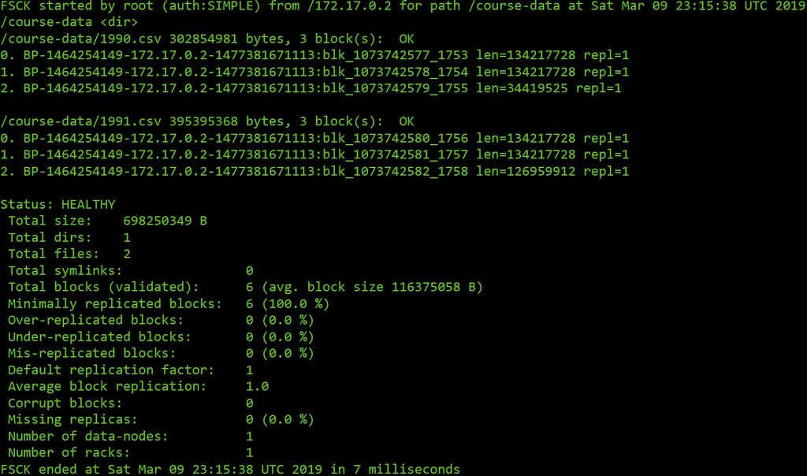

# Question 3 (4 pts)

Remember in Question 2, we copied two files in Hadoop file system. For the below questions, you will use file browser, via Apache Ambari, to view the files and perform operation.

## a)

Attach the screenshot of the file browser showing the two files copied in Hadoop filesystem. The screenshot should show the file size and permissions as well.

[figure not shown]

## b)

Delete the file **1990.csv** using the file browser. Attach the screenshot of the file browser after the operation. Please write down the Hadoop command that performs the same operation.

[figure not shown]

[figure not shown]

```
hadoop fs -rm /course-data/1990.csv
```

# Question 4 (66 pts)

In this question, you will practice data analysis using MapReduce in Hadoop with the streaming method. You will modify the mapper and reducer programs written in Python to make them more general and robust and to add more functionality so that they do more than just counting the word frequencies. In Hortonworks Sandbox, in CentOS (through localhost:4200), create a new directory called **HW2Q4** at the root, and save all the related files in this directory.

You are required to use vi to code your Python map and reduce programs. In your code, you must use comments to include your name at the beginning of each program file and to explain what your code blocks do in the program, such as the meaning of the variables you define and the task that your “for loop” performs, etc. These comments are very important for the grader to understand your code. **If the comments are missing (or too simple), up to 10 points may be taken away.** You are required to list all the Linux or Hadoop commands and steps you use to perform the tasks below. Your Python map and reduce programs should be saved to separate files with a **.py** extension.

```
[root@sandbox /]# mkdir /HW2Q4
```

```
[root@sandbox /]# ls
bin   cgroups_test  dev  hadoop  HW2Q4       lib    lost+found  mnt        opt           proc  sbin     srv  tmp  vagrant
boot  data-set      etc  home    kafka-logs  lib64  media       nohup.out  packer-files  root  selinux  sys  usr  var
```

## a) (30 pts)

The map and the reduce programs (**WDmapper.py** and **WDreducer.py**) introduced in the class produced the desired results when we tested them with some simple and short texts; however, when we apply these to complicated texts, you will find problems that some words are pre-fixed and/or post-fixed with punctuation marks, parentheses and quotes, etc. and the same words are treated as different words.

Modify **WDmapper.py** and **WDreducer.py** to fix the above problems. The input text file to use is the **shakespeare.txt** file on Blackboard. First, test your **WDmapper.py** and **WDreducer.py** files with Linux shell scripting by forming a pipeline; attach a screenshot of this result. Second, run your mapper and reducer in HDFS; download the reducer output file, **part-00000**, from the HDFS system to your host OS (Windows OS or Mac OS) and then rename it to “**Q4a_Reduceroutput.txt**”. Paste this in your solution file. Additionally, submit **WDmapper.py**, **WDreducer.py** and **Q4a_Reducer-output.txt** files.

```
[root@sandbox HW2Q4]# wget http://harrylu.net/CU/5065/WDmapper.py
[root@sandbox HW2Q4]# wget http://harrylu.net/CU/5065/WDreducer.py
[root@sandbox HW2Q4]# ls
shakespeare.txt  WDmapper.py  WDreducer.py
[root@sandbox HW2Q4]# chmod +x WDmapper.py
[root@sandbox HW2Q4]# chmod +x WDreducer.py
[root@sandbox HW2Q4]# ls -lh
total 5.1M
-rw-r--r-- 1 root root 5.1M Mar 13 01:27 shakespeare.txt
-rwxr-xr-x 1 root root  533 Mar 13 01:59 WDmapper.py
-rwxr-xr-x 1 root root  810 Mar 13 01:59 WDreducer.py
```

```
[root@sandbox HW2Q4]# cat shakespeare.txt | ./WDmapper.py | ./WDreducer.py
```

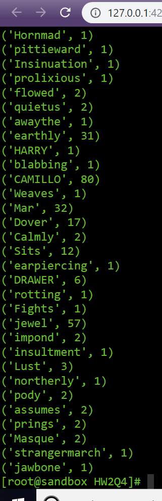

```
[root@sandbox HW2Q4]# cat shakespeare.txt | ./WDmapper.py | ./WDreducer.py | less
```

[figure not shown]

[output not shown]

## b) (26 pts)

Further modify **WDmapper.py** and **WDreducer.py** and rename them to **WDmapper1.py** and **WDreducer1.py** respectively so that you only output the following (you should not output the whole word list and word frequencies).

Here the same words with different cases are treated as different words, e.g., “University” and “university” are different words. Again, your output words should only contain the words themselves, i.e., no punctuation marks, quotes, etc. at the beginning and/or the end (same below). Download the reducer output file, **part-00000**, from the HDFS system to your host OS and then rename it to “**Q4b_Reducer-output.txt**”. Paste this in your solution file. Additionally, submit **WDmapper1.py**, **WDreducer1.py** and **Q4b_Reducer-output.txt** files.

```
[root@sandbox HW2Q4]# wget http://harrylu.net/CU/5065/WDmapper1.py
[root@sandbox HW2Q4]# wget http://harrylu.net/CU/5065/WDreducer1.py
[root@sandbox HW2Q4]# chmod +x WDmapper1.py
[root@sandbox HW2Q4]# chmod +x WDreducer1.py
```

```
[root@sandbox HW2Q4]# cat shakespeare.txt | ./WDmapper1.py | ./WDreducer1.py
```

```
[root@sandbox HW2Q4]# hadoop jar /usr/hdp/2.5.0.0-1245/hadoop-mapreduce/hadoop-streaming.jar -file WDmapper1.py -file WDreducer1.py -mapper WDmapper1.py -reducer WDreducer1.py -input /course-data/shakespeare.txt -output /course-data/Q4b_output
```

### 1)

The total number of the lines of **shakespeare.txt**.

```
There are 121983 lines in the text.
```

### 2)

The 100 most frequently used words in shakespeare.txt, including the words and their counts. (Hint: you should consider using the Python `lambda` operator/function and the `sort()` function)

```
The 100 most frequently used words are:

('the', 23222)
('I', 20365)
('and', 18562)
('to', 15801)
('of', 15665)
('a', 12650)
('you', 12013)
('my', 10830)
('in', 9847)
('is', 8278)
('that', 8055)
('not', 8019)
('me', 7744)
('And', 7455)
('with', 6777)
('it', 6716)
('be', 6369)
('his', 6320)
('your', 6002)
('for', 5773)
('this', 5461)
('have', 5427)
('him', 5161)
('he', 4838)
('thou', 4558)
('will', 4502)
('as', 4301)
('The', 4016)
('so', 4009)
('her', 3656)
('but', 3653)
('thy', 3632)
('all', 3405)
('To', 3346)
('do', 3228)
('thee', 3159)
('shall', 3120)
('are', 3081)
('by', 2915)
('That', 2833)
('on', 2832)
('no', 2707)
('our', 2684)
('But', 2612)
('we', 2561)
('What', 2321)
('from', 2288)
('at', 2268)
('good', 2264)
('O', 2261)
('what', 2141)
('am', 2109)
('more', 2065)
('would', 2021)
('lord', 2018)
('was', 2017)
('Enter', 1986)
('now', 1979)
('them', 1978)
('love', 1955)
('A', 1943)
('their', 1933)
('they', 1899)
('if', 1837)
('For', 1783)
('man', 1781)
('sir', 1755)
('Ill', 1753)
('or', 1745)
('she', 1741)
('well', 1734)
('If', 1655)
('My', 1649)
('hath', 1649)
('us', 1616)
('here', 1583)
('one', 1582)
('You', 1575)
('know', 1568)
('an', 1561)
('come', 1557)
('then', 1527)
('like', 1511)
('say', 1469)
('make', 1465)
('than', 1453)
('As', 1429)
('may', 1423)
('should', 1421)
('He', 1412)
('which', 1410)
('upon', 1403)
('were', 1387)
('did', 1385)
('must', 1351)
('KING', 1322)
('there', 1318)
('see', 1307)
('let', 1287)
('had', 1274)
```

### 3)

The total number of the words in **shakespeare.txt**.

```
There are 882854 words in the text.
```

### 4)

The number of unique words in the **shakespeare.txt**.

```
There are 34041 unique words in the text.
```

## c) (10 pts)

If the case difference of the words is ignored, modify your above Python programs and rename them to **WDmapper2.py** and **WDreducer2.py**. Repeat similar sub-questions as in b):

Download the reducer output file, **part-00000**, from the HDFS system to your host OS and then rename it to “**Q4c_Reducer-output.txt**”. Paste the output in your solution file. Additionally, submit **WDmapper2.py**, **WDreducer2.py** and **Q4c_Reducer-output.txt** files.

```
[root@sandbox HW2Q4]# wget http://harrylu.net/CU/5065/WDmapper2.py
[root@sandbox HW2Q4]# wget http://harrylu.net/CU/5065/WDreducer2.py
[root@sandbox HW2Q4]# chmod +x WDmapper2.py
[root@sandbox HW2Q4]# chmod +x WDreducer2.py
```

```
[root@sandbox HW2Q4]# cat shakespeare.txt | ./WDmapper2.py | ./WDreducer2.py
```

```
[root@sandbox HW2Q4]# hadoop jar /usr/hdp/2.5.0.0-1245/hadoop-mapreduce/hadoop-streaming.jar -file WDmapper2.py -file WDreducer2.py -mapper WDmapper2.py -reducer WDreducer2.py -input /course-data/shakespeare.txt -output /course-data/Q4c_output
```

### 1)

The total number of the lines of **shakespeare.txt**.

```
There are 121983 lines in the text.
```

### 2)

The 100 most frequently used words in **shakespeare.txt**, including the words and their counts.

```
The 100 most frequently used words are:

('the', 27356)
('and', 26026)
('i', 20675)
('to', 19147)
('of', 17459)
('a', 14593)
('you', 13611)
('my', 12479)
('in', 10953)
('that', 10889)
('is', 9134)
('not', 8496)
('with', 7770)
('me', 7769)
('it', 7677)
('for', 7557)
('his', 6857)
('be', 6856)
('your', 6653)
('this', 6601)
('but', 6265)
('he', 6250)
('have', 5879)
('as', 5731)
('thou', 5485)
('him', 5191)
('so', 5043)
('will', 4972)
('what', 4463)
('thy', 4032)
('all', 3883)
('her', 3843)
('no', 3790)
('do', 3748)
('by', 3729)
('shall', 3588)
('if', 3492)
('are', 3402)
('we', 3293)
('thee', 3178)
('lord', 3059)
('our', 3057)
('on', 3044)
('king', 2860)
('good', 2812)
('now', 2777)
('sir', 2754)
('from', 2639)
('o', 2607)
('come', 2507)
('at', 2501)
('they', 2470)
('well', 2462)
('or', 2425)
('which', 2314)
('would', 2293)
('more', 2288)
('was', 2229)
('then', 2221)
('she', 2208)
('am', 2168)
('how', 2159)
('here', 2114)
('let', 2099)
('enter', 2097)
('their', 2075)
('love', 2053)
('when', 2049)
('them', 1978)
('ill', 1972)
('hath', 1941)
('than', 1879)
('man', 1835)
('an', 1832)
('there', 1808)
('one', 1779)
('go', 1733)
('upon', 1731)
('like', 1700)
('say', 1679)
('know', 1646)
('may', 1632)
('make', 1629)
('did', 1626)
('us', 1618)
('were', 1577)
('should', 1572)
('yet', 1569)
('must', 1491)
('why', 1465)
('see', 1437)
('had', 1427)
('tis', 1405)
('such', 1389)
('out', 1376)
('some', 1337)
('give', 1326)
('these', 1322)
('too', 1232)
('where', 1232)
```

### 3)

The total number of the words of **shakespeare.txt**. Here you use the same case for all the words in the text.

```
There are 882854 words in the text.
```

### 4)

The number of unique words in the **shakespeare.txt**.

```
If the case difference is ignored, there are 28144 unique words in the text.
```